# Customer Churn Prediction

Heba El-Shimy  
IBM **Cloud** Developer Advocate

<sub>GitHub: HebaNAS</sub>  
<sub>Twitter: @heba_el_shimy</sub>

Link for the notebook: https://github.com/HebaNAS/Customer-Churn-Prediction/blob/master/notebook/Customer-Churn-Prediction-Pipeline.ipynb

- Customers are considered one of the most important assets for a business
- In a competitive market, companies in which the customers have numerous choices of service providers they can easily switch a service or even the provider.
- Such customers are referred to as churned customers.<sup>[1](#first)</sup>

### Churned Customer

Customers or subscribers who stop using a company's service.

### Significance and reasons of Customer

### Churn <sup>[2](#second), [3](#third)</sup>

Customer churn is more often due to **bad brand experiences** rather than bad products.

[figure not shown]

Each year,

# $62 billion

is lost by U.S. companies following a bad customer experience

[figure not shown]

For every dollar invested in improving the customer experience, businesses see

# 3-5x

return

Finding new customers costs

# 5x

more than keeping them

Repeat customers spend

# 3x

more than new ones.

And just **20%** of them account for **80%** of a company’s future profits

Reducing churn by **5%**, businesses can increase profits anywhere from

# 25% - 125%

[figure not shown]

# Pipeline

### 1. Loading Libraries

```python
import os
import pandas as pd
import numpy as np
import seaborn as sns
import matplotlib.pyplot as plt
from sklearn import preprocessing, svm
from itertools import combinations
from sklearn.preprocessing import PolynomialFeatures, LabelEncoder, StandardScaler
import sklearn.feature_selection
from sklearn.model_selection import train_test_split
from collections import defaultdict
from sklearn import metrics
import pixiedust
```

### The Dataset

From a telecommunications company. It includes information about:

- Customers who left within the last month – the column is called Churn
- Services that each customer has signed up for – phone, multiple lines, internet, online security, online backup, device protection, tech support, and streaming TV and movies
- Customer account information – how long they’ve been a customer, contract, payment method, paperless billing, monthly charges, and total charges
- Demographic info about customers – gender, age range, and if they have partners and dependents

Link for getting the dataset: https://community.watsonanalytics.com/wp-content/uploads/2015/03/WA_Fn-UseC_-Telco-Customer-Churn.csv

Link for other datasets: https://www.ibm.com/communities/analytics/watson-analytics-blog/guide-to-sample-datasets/

### 2. Loading Our Dataset

```python
# The code was removed by Watson Studio for sharing.
```

```python
# Checking that everything is correct
pd.set_option('display.max_columns', 30)
customer_data.head(10)
```

|  | customerID | gender | SeniorCitizen | Partner | Dependents | tenure | PhoneService | MultipleLines | InternetService | OnlineSecurity | OnlineBackup | DeviceProtection | TechSupport | StreamingTV | StreamingMovies | Contract | PaperlessBilling | PaymentMethod | MonthlyCharges | TotalCharges | Churn |
| --- | --- | --- | --- | --- | --- | --- | --- | --- | --- | --- | --- | --- | --- | --- | --- | --- | --- | --- | --- | --- | --- |
| 0 | 7590-VHVEG | Female | 0 | Yes | No | 1 | No | No phone service | DSL | No | Yes | No | No | No | No | Month-to-month | Yes | Electronic check | 29.85 | 29.85 | No |
| 1 | 5575-GNVDE | Male | 0 | No | No | 34 | Yes | No | DSL | Yes | No | Yes | No | No | No | One year | No | Mailed check | 56.95 | 1889.5 | No |
| 2 | 3668-QPYBK | Male | 0 | No | No | 2 | Yes | No | DSL | Yes | Yes | No | No | No | No | Month-to-month | Yes | Mailed check | 53.85 | 108.15 | Yes |
| 3 | 7795-CFOCW | Male | 0 | No | No | 45 | No | No phone service | DSL | Yes | No | Yes | Yes | No | No | One year | No | Bank transfer (automatic) | 42.30 | 1840.75 | No |
| 4 | 9237-HQITU | Female | 0 | No | No | 2 | Yes | No | Fiber optic | No | No | No | No | No | No | Month-to-month | Yes | Electronic check | 70.70 | 151.65 | Yes |
| 5 | 9305-CDSKC | Female | 0 | No | No | 8 | Yes | Yes | Fiber optic | No | No | Yes | No | Yes | Yes | Month-to-month | Yes | Electronic check | 99.65 | 820.5 | Yes |
| 6 | 1452-KIOVK | Male | 0 | No | Yes | 22 | Yes | Yes | Fiber optic | No | Yes | No | No | Yes | No | Month-to-month | Yes | Credit card (automatic) | 89.10 | 1949.4 | No |
| 7 | 6713-OKOMC | Female | 0 | No | No | 10 | No | No phone service | DSL | Yes | No | No | No | No | No | Month-to-month | No | Mailed check | 29.75 | 301.9 | No |
| 8 | 7892-POOKP | Female | 0 | Yes | No | 28 | Yes | Yes | Fiber optic | No | No | Yes | Yes | Yes | Yes | Month-to-month | Yes | Electronic check | 104.80 | 3046.05 | Yes |
| 9 | 6388-TABGU | Male | 0 | No | Yes | 62 | Yes | No | DSL | Yes | Yes | No | No | No | No | One year | No | Bank transfer (automatic) | 56.15 | 3487.95 | No |

### 3. Get some info about our Dataset and whether we have missing values

```python
# After running this cell we will see that we have no missing values
customer_data.info()
```

```
<class 'pandas.core.frame.DataFrame'>
RangeIndex: 7043 entries, 0 to 7042
Data columns (total 21 columns):
customerID          7043 non-null object
gender              7043 non-null object
SeniorCitizen       7043 non-null int64
Partner             7043 non-null object
Dependents          7043 non-null object
tenure              7043 non-null int64
PhoneService        7043 non-null object
MultipleLines       7043 non-null object
InternetService     7043 non-null object
OnlineSecurity      7043 non-null object
OnlineBackup        7043 non-null object
DeviceProtection    7043 non-null object
TechSupport         7043 non-null object
StreamingTV         7043 non-null object
StreamingMovies     7043 non-null object
Contract            7043 non-null object
PaperlessBilling    7043 non-null object
PaymentMethod       7043 non-null object
MonthlyCharges      7043 non-null float64
TotalCharges        7043 non-null object
Churn               7043 non-null object
dtypes: float64(1), int64(2), object(18)
memory usage: 1.1+ MB
```

```python
# Drop customerID column
customer_data = customer_data.drop('customerID', axis=1)
customer_data.head(5)
```

|  | gender | SeniorCitizen | Partner | Dependents | tenure | PhoneService | MultipleLines | InternetService | OnlineSecurity | OnlineBackup | DeviceProtection | TechSupport | StreamingTV | StreamingMovies | Contract | PaperlessBilling | PaymentMethod | MonthlyCharges | TotalCharges | Churn |
| --- | --- | --- | --- | --- | --- | --- | --- | --- | --- | --- | --- | --- | --- | --- | --- | --- | --- | --- | --- | --- |
| 0 | Female | 0 | Yes | No | 1 | No | No phone service | DSL | No | Yes | No | No | No | No | Month-to-month | Yes | Electronic check | 29.85 | 29.85 | No |
| 1 | Male | 0 | No | No | 34 | Yes | No | DSL | Yes | No | Yes | No | No | No | One year | No | Mailed check | 56.95 | 1889.5 | No |
| 2 | Male | 0 | No | No | 2 | Yes | No | DSL | Yes | Yes | No | No | No | No | Month-to-month | Yes | Mailed check | 53.85 | 108.15 | Yes |
| 3 | Male | 0 | No | No | 45 | No | No phone service | DSL | Yes | No | Yes | Yes | No | No | One year | No | Bank transfer (automatic) | 42.30 | 1840.75 | No |
| 4 | Female | 0 | No | No | 2 | Yes | No | Fiber optic | No | No | No | No | No | No | Month-to-month | Yes | Electronic check | 70.70 | 151.65 | Yes |

```python
# Convert TotalCharges column to numeric as it is detected as object
new_col = pd.to_numeric(customer_data.iloc[:, 18], errors='coerce')
new_col
```

```
0         29.85
1       1889.50
2        108.15
3       1840.75
4        151.65
5        820.50
6       1949.40
7        301.90
8       3046.05
9       3487.95
10       587.45
11       326.80
12      5681.10
13      5036.30
14      2686.05
```

[output cut: 47 more lines]

```python
# Modify our dataframe to reflect the new datatype
customer_data.iloc[:, 18] = pd.Series(new_col)
customer_data
```

|  | gender | SeniorCitizen | Partner | Dependents | tenure | PhoneService | MultipleLines | InternetService | OnlineSecurity | OnlineBackup | DeviceProtection | TechSupport | StreamingTV | StreamingMovies | Contract | PaperlessBilling | PaymentMethod | MonthlyCharges | TotalCharges | Churn |
| --- | --- | --- | --- | --- | --- | --- | --- | --- | --- | --- | --- | --- | --- | --- | --- | --- | --- | --- | --- | --- |
| 0 | Female | 0 | Yes | No | 1 | No | No phone service | DSL | No | Yes | No | No | No | No | Month-to-month | Yes | Electronic check | 29.85 | 29.85 | No |
| 1 | Male | 0 | No | No | 34 | Yes | No | DSL | Yes | No | Yes | No | No | No | One year | No | Mailed check | 56.95 | 1889.50 | No |
| 2 | Male | 0 | No | No | 2 | Yes | No | DSL | Yes | Yes | No | No | No | No | Month-to-month | Yes | Mailed check | 53.85 | 108.15 | Yes |
| 3 | Male | 0 | No | No | 45 | No | No phone service | DSL | Yes | No | Yes | Yes | No | No | One year | No | Bank transfer (automatic) | 42.30 | 1840.75 | No |
| 4 | Female | 0 | No | No | 2 | Yes | No | Fiber optic | No | No | No | No | No | No | Month-to-month | Yes | Electronic check | 70.70 | 151.65 | Yes |
| 5 | Female | 0 | No | No | 8 | Yes | Yes | Fiber optic | No | No | Yes | No | Yes | Yes | Month-to-month | Yes | Electronic check | 99.65 | 820.50 | Yes |
| 6 | Male | 0 | No | Yes | 22 | Yes | Yes | Fiber optic | No | Yes | No | No | Yes | No | Month-to-month | Yes | Credit card (automatic) | 89.10 | 1949.40 | No |
| 7 | Female | 0 | No | No | 10 | No | No phone service | DSL | Yes | No | No | No | No | No | Month-to-month | No | Mailed check | 29.75 | 301.90 | No |
| 8 | Female | 0 | Yes | No | 28 | Yes | Yes | Fiber optic | No | No | Yes | Yes | Yes | Yes | Month-to-month | Yes | Electronic check | 104.80 | 3046.05 | Yes |
| 9 | Male | 0 | No | Yes | 62 | Yes | No | DSL | Yes | Yes | No | No | No | No | One year | No | Bank transfer (automatic) | 56.15 | 3487.95 | No |
| 10 | Male | 0 | Yes | Yes | 13 | Yes | No | DSL | Yes | No | No | No | No | No | Month-to-month | Yes | Mailed check | 49.95 | 587.45 | No |
| 11 | Male | 0 | No | No | 16 | Yes | No | No | No internet service | No internet service | No internet service | No internet service | No internet service | No internet service | Two year | No | Credit card (automatic) | 18.95 | 326.80 | No |
| 12 | Male | 0 | Yes | No | 58 | Yes | Yes | Fiber optic | No | No | Yes | No | Yes | Yes | One year | No | Credit card (automatic) | 100.35 | 5681.10 | No |
| 13 | Male | 0 | No | No | 49 | Yes | Yes | Fiber optic | No | Yes | Yes | No | Yes | Yes | Month-to-month | Yes | Bank transfer (automatic) | 103.70 | 5036.30 | Yes |
| 14 | Male | 0 | No | No | 25 | Yes | No | Fiber optic | Yes | No | Yes | Yes | Yes | Yes | Month-to-month | Yes | Electronic check | 105.50 | 2686.05 | No |
| 15 | Female | 0 | Yes | Yes | 69 | Yes | Yes | Fiber optic | Yes | Yes | Yes | Yes | Yes | Yes | Two year | No | Credit card (automatic) | 113.25 | 7895.15 | No |
| 16 | Female | 0 | No | No | 52 | Yes | No | No | No internet service | No internet service | No internet service | No internet service | No internet service | No internet service | One year | No | Mailed check | 20.65 | 1022.95 | No |
| 17 | Male | 0 | No | Yes | 71 | Yes | Yes | Fiber optic | Yes | No | Yes | No | Yes | Yes | Two year | No | Bank transfer (automatic) | 106.70 | 7382.25 | No |
| 18 | Female | 0 | Yes | Yes | 10 | Yes | No | DSL | No | No | Yes | Yes | No | No | Month-to-month | No | Credit card (automatic) | 55.20 | 528.35 | Yes |
| 19 | Female | 0 | No | No | 21 | Yes | No | Fiber optic | No | Yes | Yes | No | No | Yes | Month-to-month | Yes | Electronic check | 90.05 | 1862.90 | No |
| 20 | Male | 1 | No | No | 1 | No | No phone service | DSL | No | No | Yes | No | No | Yes | Month-to-month | Yes | Electronic check | 39.65 | 39.65 | Yes |
| 21 | Male | 0 | Yes | No | 12 | Yes | No | No | No internet service | No internet service | No internet service | No internet service | No internet service | No internet service | One year | No | Bank transfer (automatic) | 19.80 | 202.25 | No |
| 22 | Male | 0 | No | No | 1 | Yes | No | No | No internet service | No internet service | No internet service | No internet service | No internet service | No internet service | Month-to-month | No | Mailed check | 20.15 | 20.15 | Yes |
| 23 | Female | 0 | Yes | No | 58 | Yes | Yes | DSL | No | Yes | No | Yes | No | No | Two year | Yes | Credit card (automatic) | 59.90 | 3505.10 | No |
| 24 | Male | 0 | Yes | Yes | 49 | Yes | No | DSL | Yes | Yes | No | Yes | No | No | Month-to-month | No | Credit card (automatic) | 59.60 | 2970.30 | No |
| 25 | Female | 0 | No | No | 30 | Yes | No | DSL | Yes | Yes | No | No | No | No | Month-to-month | Yes | Bank transfer (automatic) | 55.30 | 1530.60 | No |
| 26 | Male | 0 | Yes | Yes | 47 | Yes | Yes | Fiber optic | No | Yes | No | No | Yes | Yes | Month-to-month | Yes | Electronic check | 99.35 | 4749.15 | Yes |
| 27 | Male | 0 | Yes | Yes | 1 | No | No phone service | DSL | No | Yes | No | No | No | No | Month-to-month | No | Electronic check | 30.20 | 30.20 | Yes |
| 28 | Male | 0 | Yes | No | 72 | Yes | Yes | DSL | Yes | Yes | Yes | Yes | Yes | Yes | Two year | Yes | Credit card (automatic) | 90.25 | 6369.45 | No |
| 29 | Female | 0 | No | Yes | 17 | Yes | No | DSL | No | No | No | No | Yes | Yes | Month-to-month | Yes | Mailed check | 64.70 | 1093.10 | Yes |
| ... | ... | ... | ... | ... | ... | ... | ... | ... | ... | ... | ... | ... | ... | ... | ... | ... | ... | ... | ... | ... |
| 7013 | Female | 0 | No | No | 40 | Yes | Yes | Fiber optic | No | Yes | Yes | No | Yes | No | Month-to-month | Yes | Bank transfer (automatic) | 93.40 | 3756.40 | No |
| 7014 | Male | 0 | No | No | 41 | Yes | Yes | Fiber optic | No | Yes | No | No | Yes | No | Month-to-month | Yes | Electronic check | 89.20 | 3645.75 | No |
| 7015 | Male | 1 | Yes | No | 34 | Yes | No | Fiber optic | No | No | Yes | No | Yes | No | Month-to-month | Yes | Credit card (automatic) | 85.20 | 2874.45 | No |
| 7016 | Female | 0 | No | No | 1 | Yes | No | DSL | No | Yes | No | No | No | No | Month-to-month | No | Electronic check | 49.95 | 49.95 | No |
| 7017 | Female | 0 | No | No | 51 | Yes | No | No | No internet service | No internet service | No internet service | No internet service | No internet service | No internet service | Two year | No | Bank transfer (automatic) | 20.65 | 1020.75 | No |
| 7018 | Male | 0 | Yes | Yes | 1 | Yes | No | Fiber optic | No | No | No | No | No | No | Month-to-month | Yes | Mailed check | 70.65 | 70.65 | Yes |
| 7019 | Female | 0 | No | No | 39 | Yes | No | No | No internet service | No internet service | No internet service | No internet service | No internet service | No internet service | Two year | No | Mailed check | 20.15 | 826.00 | No |
| 7020 | Male | 0 | Yes | Yes | 12 | Yes | No | No | No internet service | No internet service | No internet service | No internet service | No internet service | No internet service | Month-to-month | Yes | Electronic check | 19.20 | 239.00 | No |
| 7021 | Male | 0 | No | No | 12 | Yes | No | DSL | No | No | No | Yes | Yes | No | One year | Yes | Electronic check | 59.80 | 727.80 | Yes |
| 7022 | Male | 0 | No | No | 72 | Yes | Yes | Fiber optic | No | Yes | Yes | No | Yes | Yes | One year | Yes | Electronic check | 104.95 | 7544.30 | No |
| 7023 | Female | 1 | Yes | No | 63 | Yes | Yes | Fiber optic | No | Yes | Yes | No | Yes | Yes | Month-to-month | Yes | Electronic check | 103.50 | 6479.40 | No |
| 7024 | Male | 0 | Yes | No | 44 | Yes | Yes | Fiber optic | Yes | No | Yes | No | No | No | Month-to-month | Yes | Credit card (automatic) | 84.80 | 3626.35 | No |
| 7025 | Female | 0 | No | No | 18 | Yes | Yes | Fiber optic | No | No | Yes | Yes | No | Yes | Month-to-month | Yes | Bank transfer (automatic) | 95.05 | 1679.40 | No |
| 7026 | Female | 0 | No | No | 9 | Yes | No | DSL | No | No | No | No | No | No | Month-to-month | Yes | Bank transfer (automatic) | 44.20 | 403.35 | Yes |
| 7027 | Male | 0 | No | No | 13 | Yes | No | DSL | No | Yes | No | Yes | Yes | Yes | Month-to-month | No | Mailed check | 73.35 | 931.55 | No |
| 7028 | Female | 0 | Yes | No | 68 | Yes | No | DSL | No | Yes | No | Yes | Yes | No | Two year | No | Bank transfer (automatic) | 64.10 | 4326.25 | No |
| 7029 | Female | 1 | No | No | 6 | No | No phone service | DSL | No | No | No | No | Yes | Yes | Month-to-month | Yes | Electronic check | 44.40 | 263.05 | No |
| 7030 | Female | 0 | No | No | 2 | Yes | No | No | No internet service | No internet service | No internet service | No internet service | No internet service | No internet service | Month-to-month | Yes | Mailed check | 20.05 | 39.25 | No |
| 7031 | Male | 1 | Yes | No | 55 | Yes | Yes | DSL | Yes | Yes | No | No | No | No | One year | No | Credit card (automatic) | 60.00 | 3316.10 | No |
| 7032 | Male | 1 | No | No | 1 | Yes | Yes | Fiber optic | No | No | No | No | No | No | Month-to-month | Yes | Electronic check | 75.75 | 75.75 | Yes |
| 7033 | Male | 0 | No | No | 38 | Yes | No | Fiber optic | No | No | No | No | No | No | Month-to-month | Yes | Credit card (automatic) | 69.50 | 2625.25 | No |
| 7034 | Female | 0 | No | No | 67 | Yes | Yes | Fiber optic | Yes | Yes | Yes | No | Yes | No | Month-to-month | Yes | Credit card (automatic) | 102.95 | 6886.25 | Yes |
| 7035 | Male | 0 | No | No | 19 | Yes | No | Fiber optic | No | No | No | No | Yes | No | Month-to-month | Yes | Bank transfer (automatic) | 78.70 | 1495.10 | No |
| 7036 | Female | 0 | No | No | 12 | No | No phone service | DSL | No | Yes | Yes | Yes | Yes | Yes | One year | No | Electronic check | 60.65 | 743.30 | No |
| 7037 | Female | 0 | No | No | 72 | Yes | No | No | No internet service | No internet service | No internet service | No internet service | No internet service | No internet service | Two year | Yes | Bank transfer (automatic) | 21.15 | 1419.40 | No |
| 7038 | Male | 0 | Yes | Yes | 24 | Yes | Yes | DSL | Yes | No | Yes | Yes | Yes | Yes | One year | Yes | Mailed check | 84.80 | 1990.50 | No |
| 7039 | Female | 0 | Yes | Yes | 72 | Yes | Yes | Fiber optic | No | Yes | Yes | No | Yes | Yes | One year | Yes | Credit card (automatic) | 103.20 | 7362.90 | No |
| 7040 | Female | 0 | Yes | Yes | 11 | No | No phone service | DSL | Yes | No | No | No | No | No | Month-to-month | Yes | Electronic check | 29.60 | 346.45 | No |
| 7041 | Male | 1 | Yes | No | 4 | Yes | Yes | Fiber optic | No | No | No | No | No | No | Month-to-month | Yes | Mailed check | 74.40 | 306.60 | Yes |
| 7042 | Male | 0 | No | No | 66 | Yes | No | Fiber optic | Yes | No | Yes | Yes | Yes | Yes | Two year | Yes | Bank transfer (automatic) | 105.65 | 6844.50 | No |

7043 rows × 20 columns

```python
# Check if we have any NaN values
customer_data.isnull().values.any()
```

```
True
```

```python
# Handle missing values
from sklearn.preprocessing import Imputer

imp = Imputer(missing_values="NaN", strategy="mean")

customer_data.iloc[:, 18] = imp.fit_transform(customer_data.iloc[:, 18].values.reshape(-1, 1))
customer_data.iloc[:, 18] = pd.Series(customer_data.iloc[:, 18])
```

```python
# Check if we have any NaN values
customer_data.isnull().values.any()
```

```
False
```

```python
customer_data.info()
```

```
<class 'pandas.core.frame.DataFrame'>
RangeIndex: 7043 entries, 0 to 7042
Data columns (total 20 columns):
gender              7043 non-null object
SeniorCitizen       7043 non-null int64
Partner             7043 non-null object
Dependents          7043 non-null object
tenure              7043 non-null int64
PhoneService        7043 non-null object
MultipleLines       7043 non-null object
InternetService     7043 non-null object
OnlineSecurity      7043 non-null object
OnlineBackup        7043 non-null object
DeviceProtection    7043 non-null object
TechSupport         7043 non-null object
StreamingTV         7043 non-null object
StreamingMovies     7043 non-null object
Contract            7043 non-null object
PaperlessBilling    7043 non-null object
PaymentMethod       7043 non-null object
MonthlyCharges      7043 non-null float64
TotalCharges        7043 non-null float64
Churn               7043 non-null object
dtypes: float64(2), int64(2), object(16)
memory usage: 1.1+ MB
```

### 4. Descriptive analytics for our data

```python
# Describe columns with numerical values
pd.set_option('precision', 3)
customer_data.describe()
```

|  | SeniorCitizen | tenure | MonthlyCharges | TotalCharges |
| --- | --- | --- | --- | --- |
| count | 7043.000 | 7043.000 | 7043.000 | 7043.000 |
| mean | 0.162 | 32.371 | 64.762 | 2283.300 |
| std | 0.369 | 24.559 | 30.090 | 2265.000 |
| min | 0.000 | 0.000 | 18.250 | 18.800 |
| 25% | 0.000 | 9.000 | 35.500 | 402.225 |
| 50% | 0.000 | 29.000 | 70.350 | 1400.550 |
| 75% | 0.000 | 55.000 | 89.850 | 3786.600 |
| max | 1.000 | 72.000 | 118.750 | 8684.800 |

```python
# Describe columns with objects
customer_data.describe(exclude=np.number)
```

|  | gender | Partner | Dependents | PhoneService | MultipleLines | InternetService | OnlineSecurity | OnlineBackup | DeviceProtection | TechSupport | StreamingTV | StreamingMovies | Contract | PaperlessBilling | PaymentMethod | Churn |
| --- | --- | --- | --- | --- | --- | --- | --- | --- | --- | --- | --- | --- | --- | --- | --- | --- |
| count | 7043 | 7043 | 7043 | 7043 | 7043 | 7043 | 7043 | 7043 | 7043 | 7043 | 7043 | 7043 | 7043 | 7043 | 7043 | 7043 |
| unique | 2 | 2 | 2 | 2 | 3 | 3 | 3 | 3 | 3 | 3 | 3 | 3 | 3 | 2 | 4 | 2 |
| top | Male | No | No | Yes | No | Fiber optic | No | No | No | No | No | No | Month-to-month | Yes | Electronic check | No |
| freq | 3555 | 3641 | 4933 | 6361 | 3390 | 3096 | 3498 | 3088 | 3095 | 3473 | 2810 | 2785 | 3875 | 4171 | 2365 | 5174 |

```python
# Find correlations
customer_data.corr(method='pearson')
```

|  | SeniorCitizen | tenure | MonthlyCharges | TotalCharges |
| --- | --- | --- | --- | --- |
| SeniorCitizen | 1.000 | 0.017 | 0.220 | 0.102 |
| tenure | 0.017 | 1.000 | 0.248 | 0.825 |
| MonthlyCharges | 0.220 | 0.248 | 1.000 | 0.650 |
| TotalCharges | 0.102 | 0.825 | 0.650 | 1.000 |

### 5. Visualize our Data to understand it better

#### Plot Relationships

```python
# Using Pixiedust for visualization
display(customer_data)
```

Tenure

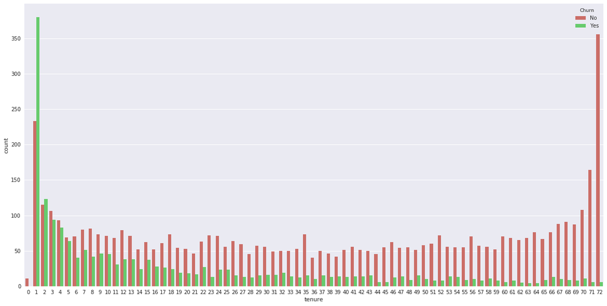

```python
# Plot Tenure Frequency count
sns.set(style="darkgrid")
sns.set_palette("hls", 3)
fig, ax = plt.subplots(figsize=(20,10))
ax = sns.countplot(x="tenure", hue="Churn", data=customer_data)
```

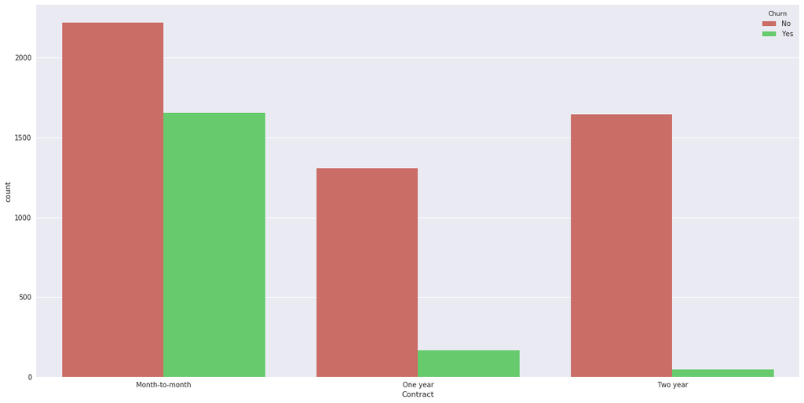

```python
# Plot Tenure Frequency count
sns.set(style="darkgrid")
sns.set_palette("hls", 3)
fig, ax = plt.subplots(figsize=(20,10))
ax = sns.countplot(x="Contract", hue="Churn", data=customer_data)
```

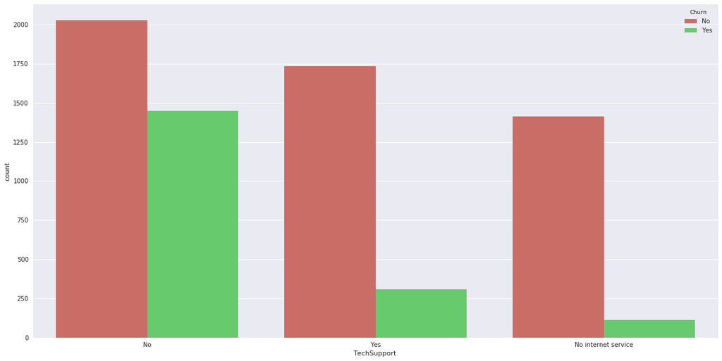

```python
# Plot Tenure Frequency count
sns.set(style="darkgrid")
sns.set_palette("hls", 3)
fig, ax = plt.subplots(figsize=(20,10))
ax = sns.countplot(x="TechSupport", hue="Churn", data=customer_data)
```

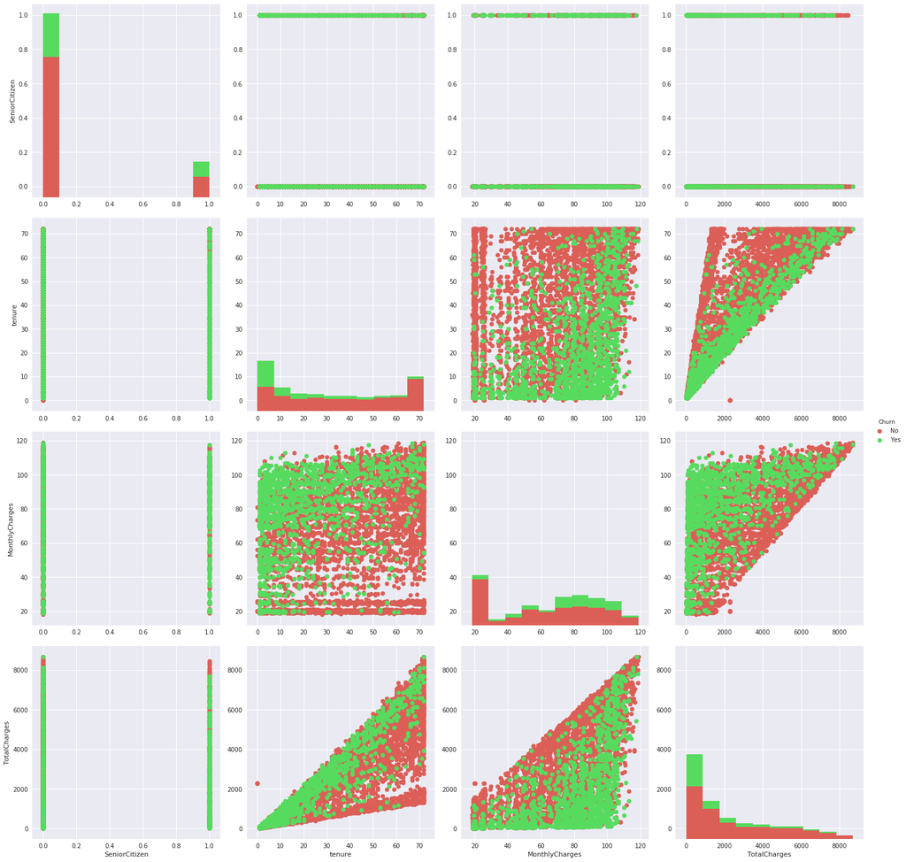

```python
# Create Grid for pairwise relationships
gr = sns.PairGrid(customer_data, size=5, hue="Churn")
gr = gr.map_diag(plt.hist)
gr = gr.map_offdiag(plt.scatter)
gr = gr.add_legend()
```

#### Understand Data Distribution

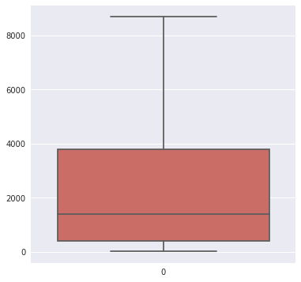

```python
# Set up plot size
fig, ax = plt.subplots(figsize=(6,6))

# Attributes destribution
a = sns.boxplot(orient="v", palette="hls", data=customer_data.iloc[:, 18], fliersize=14)
```

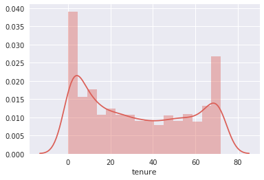

```python
# Tenure data distribution
histogram = sns.distplot(customer_data.iloc[:, 4], hist=True)
plt.show()
```

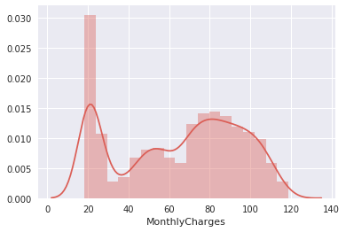

```python
# Monthly Charges data distribution
histogram = sns.distplot(customer_data.iloc[:, 17], hist=True)
plt.show()
```

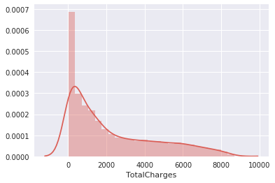

```python
# Total Charges data distribution
histogram = sns.distplot(customer_data.iloc[:, 18], hist=True)
plt.show()
```

### 6. Encode string values in data into numerical values

```python
# Use pandas get_dummies
customer_data_encoded = pd.get_dummies(customer_data)
customer_data_encoded.head(10)
```

|  | SeniorCitizen | tenure | MonthlyCharges | TotalCharges | gender_Female | gender_Male | Partner_No | Partner_Yes | Dependents_No | Dependents_Yes | PhoneService_No | PhoneService_Yes | MultipleLines_No | MultipleLines_No phone service | MultipleLines_Yes | ... | StreamingTV_Yes | StreamingMovies_No | StreamingMovies_No internet service | StreamingMovies_Yes | Contract_Month-to-month | Contract_One year | Contract_Two year | PaperlessBilling_No | PaperlessBilling_Yes | PaymentMethod_Bank transfer (automatic) | PaymentMethod_Credit card (automatic) | PaymentMethod_Electronic check | PaymentMethod_Mailed check | … |
| --- | --- | --- | --- | --- | --- | --- | --- | --- | --- | --- | --- | --- | --- | --- | --- | --- | --- | --- | --- | --- | --- | --- | --- | --- | --- | --- | --- | --- | --- | --- |
| 0 | 0 | 1 | 29.85 | 29.85 | 1 | 0 | 0 | 1 | 1 | 0 | 1 | 0 | 0 | 1 | 0 | ... | 0 | 1 | 0 | 0 | 1 | 0 | 0 | 0 | 1 | 0 | 0 | 1 | 0 | … |
| 1 | 0 | 34 | 56.95 | 1889.50 | 0 | 1 | 1 | 0 | 1 | 0 | 0 | 1 | 1 | 0 | 0 | ... | 0 | 1 | 0 | 0 | 0 | 1 | 0 | 1 | 0 | 0 | 0 | 0 | 1 | … |
| 2 | 0 | 2 | 53.85 | 108.15 | 0 | 1 | 1 | 0 | 1 | 0 | 0 | 1 | 1 | 0 | 0 | ... | 0 | 1 | 0 | 0 | 1 | 0 | 0 | 0 | 1 | 0 | 0 | 0 | 1 | … |
| 3 | 0 | 45 | 42.30 | 1840.75 | 0 | 1 | 1 | 0 | 1 | 0 | 1 | 0 | 0 | 1 | 0 | ... | 0 | 1 | 0 | 0 | 0 | 1 | 0 | 1 | 0 | 1 | 0 | 0 | 0 | … |
| 4 | 0 | 2 | 70.70 | 151.65 | 1 | 0 | 1 | 0 | 1 | 0 | 0 | 1 | 1 | 0 | 0 | ... | 0 | 1 | 0 | 0 | 1 | 0 | 0 | 0 | 1 | 0 | 0 | 1 | 0 | … |
| 5 | 0 | 8 | 99.65 | 820.50 | 1 | 0 | 1 | 0 | 1 | 0 | 0 | 1 | 0 | 0 | 1 | ... | 1 | 0 | 0 | 1 | 1 | 0 | 0 | 0 | 1 | 0 | 0 | 1 | 0 | … |
| 6 | 0 | 22 | 89.10 | 1949.40 | 0 | 1 | 1 | 0 | 0 | 1 | 0 | 1 | 0 | 0 | 1 | ... | 1 | 1 | 0 | 0 | 1 | 0 | 0 | 0 | 1 | 0 | 1 | 0 | 0 | … |
| 7 | 0 | 10 | 29.75 | 301.90 | 1 | 0 | 1 | 0 | 1 | 0 | 1 | 0 | 0 | 1 | 0 | ... | 0 | 1 | 0 | 0 | 1 | 0 | 0 | 1 | 0 | 0 | 0 | 0 | 1 | … |
| 8 | 0 | 28 | 104.80 | 3046.05 | 1 | 0 | 0 | 1 | 1 | 0 | 0 | 1 | 0 | 0 | 1 | ... | 1 | 0 | 0 | 1 | 1 | 0 | 0 | 0 | 1 | 0 | 0 | 1 | 0 | … |
| 9 | 0 | 62 | 56.15 | 3487.95 | 0 | 1 | 1 | 0 | 0 | 1 | 0 | 1 | 1 | 0 | 0 | ... | 0 | 1 | 0 | 0 | 0 | 1 | 0 | 1 | 0 | 1 | 0 | 0 | 0 | … |

10 rows × 47 columns

### 7. Create Training Set and Labels

```python
# Create training data for non-preprocessed approach
X_npp = customer_data.iloc[:, :-1].apply(LabelEncoder().fit_transform)
pd.DataFrame(X_npp).head(5)
```

|  | gender | SeniorCitizen | Partner | Dependents | tenure | PhoneService | MultipleLines | InternetService | OnlineSecurity | OnlineBackup | DeviceProtection | TechSupport | StreamingTV | StreamingMovies | Contract | PaperlessBilling | PaymentMethod | MonthlyCharges | TotalCharges |
| --- | --- | --- | --- | --- | --- | --- | --- | --- | --- | --- | --- | --- | --- | --- | --- | --- | --- | --- | --- |
| 0 | 0 | 0 | 1 | 0 | 1 | 0 | 1 | 0 | 0 | 2 | 0 | 0 | 0 | 0 | 0 | 1 | 2 | 142 | 74 |
| 1 | 1 | 0 | 0 | 0 | 34 | 1 | 0 | 0 | 2 | 0 | 2 | 0 | 0 | 0 | 1 | 0 | 3 | 498 | 3624 |
| 2 | 1 | 0 | 0 | 0 | 2 | 1 | 0 | 0 | 2 | 2 | 0 | 0 | 0 | 0 | 0 | 1 | 3 | 436 | 536 |
| 3 | 1 | 0 | 0 | 0 | 45 | 0 | 1 | 0 | 2 | 0 | 2 | 2 | 0 | 0 | 1 | 0 | 0 | 266 | 3570 |
| 4 | 0 | 0 | 0 | 0 | 2 | 1 | 0 | 1 | 0 | 0 | 0 | 0 | 0 | 0 | 0 | 1 | 2 | 729 | 674 |

```python
# Create training data for that will undergo preprocessing
X = customer_data_encoded.iloc[:, :-2]
X.head()
```

|  | SeniorCitizen | tenure | MonthlyCharges | TotalCharges | gender_Female | gender_Male | Partner_No | Partner_Yes | Dependents_No | Dependents_Yes | PhoneService_No | PhoneService_Yes | MultipleLines_No | MultipleLines_No phone service | MultipleLines_Yes | ... | StreamingTV_No | StreamingTV_No internet service | StreamingTV_Yes | StreamingMovies_No | StreamingMovies_No internet service | StreamingMovies_Yes | Contract_Month-to-month | Contract_One year | Contract_Two year | PaperlessBilling_No | PaperlessBilling_Yes | PaymentMethod_Bank transfer (automatic) | PaymentMethod_Credit card (automatic) | … |
| --- | --- | --- | --- | --- | --- | --- | --- | --- | --- | --- | --- | --- | --- | --- | --- | --- | --- | --- | --- | --- | --- | --- | --- | --- | --- | --- | --- | --- | --- | --- |
| 0 | 0 | 1 | 29.85 | 29.85 | 1 | 0 | 0 | 1 | 1 | 0 | 1 | 0 | 0 | 1 | 0 | ... | 1 | 0 | 0 | 1 | 0 | 0 | 1 | 0 | 0 | 0 | 1 | 0 | 0 | … |
| 1 | 0 | 34 | 56.95 | 1889.50 | 0 | 1 | 1 | 0 | 1 | 0 | 0 | 1 | 1 | 0 | 0 | ... | 1 | 0 | 0 | 1 | 0 | 0 | 0 | 1 | 0 | 1 | 0 | 0 | 0 | … |
| 2 | 0 | 2 | 53.85 | 108.15 | 0 | 1 | 1 | 0 | 1 | 0 | 0 | 1 | 1 | 0 | 0 | ... | 1 | 0 | 0 | 1 | 0 | 0 | 1 | 0 | 0 | 0 | 1 | 0 | 0 | … |
| 3 | 0 | 45 | 42.30 | 1840.75 | 0 | 1 | 1 | 0 | 1 | 0 | 1 | 0 | 0 | 1 | 0 | ... | 1 | 0 | 0 | 1 | 0 | 0 | 0 | 1 | 0 | 1 | 0 | 1 | 0 | … |
| 4 | 0 | 2 | 70.70 | 151.65 | 1 | 0 | 1 | 0 | 1 | 0 | 0 | 1 | 1 | 0 | 0 | ... | 1 | 0 | 0 | 1 | 0 | 0 | 1 | 0 | 0 | 0 | 1 | 0 | 0 | … |

5 rows × 45 columns

```python
# Extract labels
y_unenc = customer_data['Churn']
```

```python
# Convert strings of 'yes' and 'no' to binary values of 0 or 1
le = preprocessing.LabelEncoder()
le.fit(y_unenc)

y_le = le.transform(y_unenc)
pd.DataFrame(y_le)
```

|  | 0 |
| --- | --- |
| 0 | 0 |
| 1 | 0 |
| 2 | 1 |
| 3 | 0 |
| 4 | 1 |
| 5 | 1 |
| 6 | 0 |
| 7 | 0 |
| 8 | 1 |
| 9 | 0 |
| 10 | 0 |
| 11 | 0 |
| 12 | 0 |
| 13 | 1 |
| 14 | 0 |
| 15 | 0 |
| 16 | 0 |
| 17 | 0 |
| 18 | 1 |
| 19 | 0 |
| 20 | 1 |
| 21 | 0 |
| 22 | 1 |
| 23 | 0 |
| 24 | 0 |
| 25 | 0 |
| 26 | 1 |
| 27 | 1 |
| 28 | 0 |
| 29 | 1 |
| ... | ... |
| 7013 | 0 |
| 7014 | 0 |
| 7015 | 0 |
| 7016 | 0 |
| 7017 | 0 |
| 7018 | 1 |
| 7019 | 0 |
| 7020 | 0 |
| 7021 | 1 |
| 7022 | 0 |
| 7023 | 0 |
| 7024 | 0 |
| 7025 | 0 |
| 7026 | 1 |
| 7027 | 0 |
| 7028 | 0 |
| 7029 | 0 |
| 7030 | 0 |
| 7031 | 0 |
| 7032 | 1 |
| 7033 | 0 |
| 7034 | 1 |
| 7035 | 0 |
| 7036 | 0 |
| 7037 | 0 |
| 7038 | 0 |
| 7039 | 0 |
| 7040 | 0 |
| 7041 | 1 |
| 7042 | 0 |

7043 rows × 1 columns

### 8. Detect outliers in numerical values

```python
# Calculate the Z-score using median value and median absolute deviation for more robust calculations
# Working on Monthly Charges column
threshold = 3

median = np.median(X['MonthlyCharges'])
median_absolute_deviation = np.median([np.abs(x - median) for x in X['MonthlyCharges']])
modified_z_scores = [0.6745 * (x - median) / median_absolute_deviation
                         for x in X['MonthlyCharges']]
results = np.abs(modified_z_scores) > threshold

print(np.any(results))
```

```
False
```

```python
# Do the same for Total Charges column but using the interquartile method

quartile_1, quartile_3 = np.percentile(X['TotalCharges'], [25, 75])
iqr = quartile_3 - quartile_1
lower_bound = quartile_1 - (iqr * 1.5)
upper_bound = quartile_3 + (iqr * 1.5)

print(np.where((X['TotalCharges'] > upper_bound) | (X['TotalCharges'] < lower_bound)))
```

```
(array([], dtype=int64),)
```

### 9. Feature Engineering

```python
# Find interactions between current features and append them to the dataframe
def add_interactions(dataset):
    # Get feature names
    comb = list(combinations(list(dataset.columns), 2))
    col_names = list(dataset.columns) + ['_'.join(x) for x in comb]

    # Find interactions
    poly = PolynomialFeatures(interaction_only=True, include_bias=False)
    dataset = poly.fit_transform(dataset)
    dataset = pd.DataFrame(dataset)
    dataset.columns = col_names

    # Remove interactions with 0 values
    no_inter_indexes = [i for i, x in enumerate(list((dataset ==0).all())) if x]
    dataset = dataset.drop(dataset.columns[no_inter_indexes], axis=1)

    return dataset
```

```python
X_inter = add_interactions(X)
X_inter.head(15)
```

|  | SeniorCitizen | tenure | MonthlyCharges | TotalCharges | gender_Female | gender_Male | Partner_No | Partner_Yes | Dependents_No | Dependents_Yes | PhoneService_No | PhoneService_Yes | MultipleLines_No | MultipleLines_No phone service | MultipleLines_Yes | ... | Contract_One year_PaymentMethod_Mailed check | Contract_Two year_PaperlessBilling_No | Contract_Two year_PaperlessBilling_Yes | Contract_Two year_PaymentMethod_Bank transfer (automatic) | Contract_Two year_PaymentMethod_Credit card (automatic) | Contract_Two year_PaymentMethod_Electronic check | Contract_Two year_PaymentMethod_Mailed check | PaperlessBilling_No_PaymentMethod_Bank transfer (automatic) | PaperlessBilling_No_PaymentMethod_Credit card (automatic) | PaperlessBilling_No_PaymentMethod_Electronic check | PaperlessBilling_No_PaymentMethod_Mailed check | PaperlessBilling_Yes_PaymentMethod_Bank transfer (automatic) | PaperlessBilling_Yes_PaymentMethod_Credit card (automatic) | … |
| --- | --- | --- | --- | --- | --- | --- | --- | --- | --- | --- | --- | --- | --- | --- | --- | --- | --- | --- | --- | --- | --- | --- | --- | --- | --- | --- | --- | --- | --- | --- |
| 0 | 0.0 | 1.0 | 29.85 | 29.85 | 1.0 | 0.0 | 0.0 | 1.0 | 1.0 | 0.0 | 1.0 | 0.0 | 0.0 | 1.0 | 0.0 | ... | 0.0 | 0.0 | 0.0 | 0.0 | 0.0 | 0.0 | 0.0 | 0.0 | 0.0 | 0.0 | 0.0 | 0.0 | 0.0 | … |
| 1 | 0.0 | 34.0 | 56.95 | 1889.50 | 0.0 | 1.0 | 1.0 | 0.0 | 1.0 | 0.0 | 0.0 | 1.0 | 1.0 | 0.0 | 0.0 | ... | 1.0 | 0.0 | 0.0 | 0.0 | 0.0 | 0.0 | 0.0 | 0.0 | 0.0 | 0.0 | 1.0 | 0.0 | 0.0 | … |
| 2 | 0.0 | 2.0 | 53.85 | 108.15 | 0.0 | 1.0 | 1.0 | 0.0 | 1.0 | 0.0 | 0.0 | 1.0 | 1.0 | 0.0 | 0.0 | ... | 0.0 | 0.0 | 0.0 | 0.0 | 0.0 | 0.0 | 0.0 | 0.0 | 0.0 | 0.0 | 0.0 | 0.0 | 0.0 | … |
| 3 | 0.0 | 45.0 | 42.30 | 1840.75 | 0.0 | 1.0 | 1.0 | 0.0 | 1.0 | 0.0 | 1.0 | 0.0 | 0.0 | 1.0 | 0.0 | ... | 0.0 | 0.0 | 0.0 | 0.0 | 0.0 | 0.0 | 0.0 | 1.0 | 0.0 | 0.0 | 0.0 | 0.0 | 0.0 | … |
| 4 | 0.0 | 2.0 | 70.70 | 151.65 | 1.0 | 0.0 | 1.0 | 0.0 | 1.0 | 0.0 | 0.0 | 1.0 | 1.0 | 0.0 | 0.0 | ... | 0.0 | 0.0 | 0.0 | 0.0 | 0.0 | 0.0 | 0.0 | 0.0 | 0.0 | 0.0 | 0.0 | 0.0 | 0.0 | … |
| 5 | 0.0 | 8.0 | 99.65 | 820.50 | 1.0 | 0.0 | 1.0 | 0.0 | 1.0 | 0.0 | 0.0 | 1.0 | 0.0 | 0.0 | 1.0 | ... | 0.0 | 0.0 | 0.0 | 0.0 | 0.0 | 0.0 | 0.0 | 0.0 | 0.0 | 0.0 | 0.0 | 0.0 | 0.0 | … |
| 6 | 0.0 | 22.0 | 89.10 | 1949.40 | 0.0 | 1.0 | 1.0 | 0.0 | 0.0 | 1.0 | 0.0 | 1.0 | 0.0 | 0.0 | 1.0 | ... | 0.0 | 0.0 | 0.0 | 0.0 | 0.0 | 0.0 | 0.0 | 0.0 | 0.0 | 0.0 | 0.0 | 0.0 | 1.0 | … |
| 7 | 0.0 | 10.0 | 29.75 | 301.90 | 1.0 | 0.0 | 1.0 | 0.0 | 1.0 | 0.0 | 1.0 | 0.0 | 0.0 | 1.0 | 0.0 | ... | 0.0 | 0.0 | 0.0 | 0.0 | 0.0 | 0.0 | 0.0 | 0.0 | 0.0 | 0.0 | 1.0 | 0.0 | 0.0 | … |
| 8 | 0.0 | 28.0 | 104.80 | 3046.05 | 1.0 | 0.0 | 0.0 | 1.0 | 1.0 | 0.0 | 0.0 | 1.0 | 0.0 | 0.0 | 1.0 | ... | 0.0 | 0.0 | 0.0 | 0.0 | 0.0 | 0.0 | 0.0 | 0.0 | 0.0 | 0.0 | 0.0 | 0.0 | 0.0 | … |
| 9 | 0.0 | 62.0 | 56.15 | 3487.95 | 0.0 | 1.0 | 1.0 | 0.0 | 0.0 | 1.0 | 0.0 | 1.0 | 1.0 | 0.0 | 0.0 | ... | 0.0 | 0.0 | 0.0 | 0.0 | 0.0 | 0.0 | 0.0 | 1.0 | 0.0 | 0.0 | 0.0 | 0.0 | 0.0 | … |
| 10 | 0.0 | 13.0 | 49.95 | 587.45 | 0.0 | 1.0 | 0.0 | 1.0 | 0.0 | 1.0 | 0.0 | 1.0 | 1.0 | 0.0 | 0.0 | ... | 0.0 | 0.0 | 0.0 | 0.0 | 0.0 | 0.0 | 0.0 | 0.0 | 0.0 | 0.0 | 0.0 | 0.0 | 0.0 | … |
| 11 | 0.0 | 16.0 | 18.95 | 326.80 | 0.0 | 1.0 | 1.0 | 0.0 | 1.0 | 0.0 | 0.0 | 1.0 | 1.0 | 0.0 | 0.0 | ... | 0.0 | 1.0 | 0.0 | 0.0 | 1.0 | 0.0 | 0.0 | 0.0 | 1.0 | 0.0 | 0.0 | 0.0 | 0.0 | … |
| 12 | 0.0 | 58.0 | 100.35 | 5681.10 | 0.0 | 1.0 | 0.0 | 1.0 | 1.0 | 0.0 | 0.0 | 1.0 | 0.0 | 0.0 | 1.0 | ... | 0.0 | 0.0 | 0.0 | 0.0 | 0.0 | 0.0 | 0.0 | 0.0 | 1.0 | 0.0 | 0.0 | 0.0 | 0.0 | … |
| 13 | 0.0 | 49.0 | 103.70 | 5036.30 | 0.0 | 1.0 | 1.0 | 0.0 | 1.0 | 0.0 | 0.0 | 1.0 | 0.0 | 0.0 | 1.0 | ... | 0.0 | 0.0 | 0.0 | 0.0 | 0.0 | 0.0 | 0.0 | 0.0 | 0.0 | 0.0 | 0.0 | 1.0 | 0.0 | … |
| 14 | 0.0 | 25.0 | 105.50 | 2686.05 | 0.0 | 1.0 | 1.0 | 0.0 | 1.0 | 0.0 | 0.0 | 1.0 | 1.0 | 0.0 | 0.0 | ... | 0.0 | 0.0 | 0.0 | 0.0 | 0.0 | 0.0 | 0.0 | 0.0 | 0.0 | 0.0 | 0.0 | 0.0 | 0.0 | … |

15 rows × 894 columns

```python
# Select best features
select = sklearn.feature_selection.SelectKBest(k=25)
selected_features = select.fit(X_inter, y_le)
indexes = selected_features.get_support(indices=True)
col_names_selected = [X_inter.columns[i] for i in indexes]

X_selected = X_inter[col_names_selected]
X_selected.head(10)
```

|  | tenure | OnlineSecurity_No | TechSupport_No | Contract_Month-to-month | MonthlyCharges_OnlineSecurity_No | MonthlyCharges_TechSupport_No | MonthlyCharges_Contract_Month-to-month | Dependents_No_OnlineSecurity_No | Dependents_No_TechSupport_No | Dependents_No_Contract_Month-to-month | PhoneService_Yes_Contract_Month-to-month | InternetService_Fiber optic_OnlineSecurity_No | InternetService_Fiber optic_TechSupport_No | InternetService_Fiber optic_Contract_Month-to-month | InternetService_Fiber optic_PaymentMethod_Electronic check | OnlineSecurity_No_OnlineBackup_No | OnlineSecurity_No_TechSupport_No | OnlineSecurity_No_Contract_Month-to-month | OnlineSecurity_No_PaymentMethod_Electronic check | OnlineBackup_No_Contract_Month-to-month | DeviceProtection_No_Contract_Month-to-month | TechSupport_No_Contract_Month-to-month | TechSupport_No_PaymentMethod_Electronic check | Contract_Month-to-month_PaperlessBilling_Yes | Contract_Month-to-month_PaymentMethod_Electronic check |
| --- | --- | --- | --- | --- | --- | --- | --- | --- | --- | --- | --- | --- | --- | --- | --- | --- | --- | --- | --- | --- | --- | --- | --- | --- | --- |
| 0 | 1.0 | 1.0 | 1.0 | 1.0 | 29.85 | 29.85 | 29.85 | 1.0 | 1.0 | 1.0 | 0.0 | 0.0 | 0.0 | 0.0 | 0.0 | 0.0 | 1.0 | 1.0 | 1.0 | 0.0 | 1.0 | 1.0 | 1.0 | 1.0 | 1.0 |
| 1 | 34.0 | 0.0 | 1.0 | 0.0 | 0.00 | 56.95 | 0.00 | 0.0 | 1.0 | 0.0 | 0.0 | 0.0 | 0.0 | 0.0 | 0.0 | 0.0 | 0.0 | 0.0 | 0.0 | 0.0 | 0.0 | 0.0 | 0.0 | 0.0 | 0.0 |
| 2 | 2.0 | 0.0 | 1.0 | 1.0 | 0.00 | 53.85 | 53.85 | 0.0 | 1.0 | 1.0 | 1.0 | 0.0 | 0.0 | 0.0 | 0.0 | 0.0 | 0.0 | 0.0 | 0.0 | 0.0 | 1.0 | 1.0 | 0.0 | 1.0 | 0.0 |
| 3 | 45.0 | 0.0 | 0.0 | 0.0 | 0.00 | 0.00 | 0.00 | 0.0 | 0.0 | 0.0 | 0.0 | 0.0 | 0.0 | 0.0 | 0.0 | 0.0 | 0.0 | 0.0 | 0.0 | 0.0 | 0.0 | 0.0 | 0.0 | 0.0 | 0.0 |
| 4 | 2.0 | 1.0 | 1.0 | 1.0 | 70.70 | 70.70 | 70.70 | 1.0 | 1.0 | 1.0 | 1.0 | 1.0 | 1.0 | 1.0 | 1.0 | 1.0 | 1.0 | 1.0 | 1.0 | 1.0 | 1.0 | 1.0 | 1.0 | 1.0 | 1.0 |
| 5 | 8.0 | 1.0 | 1.0 | 1.0 | 99.65 | 99.65 | 99.65 | 1.0 | 1.0 | 1.0 | 1.0 | 1.0 | 1.0 | 1.0 | 1.0 | 1.0 | 1.0 | 1.0 | 1.0 | 1.0 | 0.0 | 1.0 | 1.0 | 1.0 | 1.0 |
| 6 | 22.0 | 1.0 | 1.0 | 1.0 | 89.10 | 89.10 | 89.10 | 0.0 | 0.0 | 0.0 | 1.0 | 1.0 | 1.0 | 1.0 | 0.0 | 0.0 | 1.0 | 1.0 | 0.0 | 0.0 | 1.0 | 1.0 | 0.0 | 1.0 | 0.0 |
| 7 | 10.0 | 0.0 | 1.0 | 1.0 | 0.00 | 29.75 | 29.75 | 0.0 | 1.0 | 1.0 | 0.0 | 0.0 | 0.0 | 0.0 | 0.0 | 0.0 | 0.0 | 0.0 | 0.0 | 1.0 | 1.0 | 1.0 | 0.0 | 0.0 | 0.0 |
| 8 | 28.0 | 1.0 | 0.0 | 1.0 | 104.80 | 0.00 | 104.80 | 1.0 | 0.0 | 1.0 | 1.0 | 1.0 | 0.0 | 1.0 | 1.0 | 1.0 | 0.0 | 1.0 | 1.0 | 1.0 | 0.0 | 0.0 | 0.0 | 1.0 | 1.0 |
| 9 | 62.0 | 0.0 | 1.0 | 0.0 | 0.00 | 56.15 | 0.00 | 0.0 | 0.0 | 0.0 | 0.0 | 0.0 | 0.0 | 0.0 | 0.0 | 0.0 | 0.0 | 0.0 | 0.0 | 0.0 | 0.0 | 0.0 | 0.0 | 0.0 | 0.0 |

### 10. Split our dataset into train and test datasets

#### Split non-preprocessed data

```python
X_train_npp, X_test_npp, y_train_npp, y_test_npp = train_test_split(X_npp, y_le,\
                                                    test_size=0.33, random_state=42)
print(X_train_npp.shape, y_train_npp.shape)
print(X_test_npp.shape, y_test_npp.shape)
```

```
(4718, 19) (4718,)
(2325, 19) (2325,)
```

```python
X_train, X_test, y_train, y_test = train_test_split(X_selected, y_le,\
                                                    test_size=0.33, random_state=42)
print(X_train.shape, y_train.shape)
print(X_test.shape, y_test.shape)
```

```
(4718, 25) (4718,)
(2325, 25) (2325,)
```

```python
X_test.head()
```

|  | tenure | OnlineSecurity_No | TechSupport_No | Contract_Month-to-month | MonthlyCharges_OnlineSecurity_No | MonthlyCharges_TechSupport_No | MonthlyCharges_Contract_Month-to-month | Dependents_No_OnlineSecurity_No | Dependents_No_TechSupport_No | Dependents_No_Contract_Month-to-month | PhoneService_Yes_Contract_Month-to-month | InternetService_Fiber optic_OnlineSecurity_No | InternetService_Fiber optic_TechSupport_No | InternetService_Fiber optic_Contract_Month-to-month | InternetService_Fiber optic_PaymentMethod_Electronic check | OnlineSecurity_No_OnlineBackup_No | OnlineSecurity_No_TechSupport_No | OnlineSecurity_No_Contract_Month-to-month | OnlineSecurity_No_PaymentMethod_Electronic check | OnlineBackup_No_Contract_Month-to-month | DeviceProtection_No_Contract_Month-to-month | TechSupport_No_Contract_Month-to-month | TechSupport_No_PaymentMethod_Electronic check | Contract_Month-to-month_PaperlessBilling_Yes | Contract_Month-to-month_PaymentMethod_Electronic check |
| --- | --- | --- | --- | --- | --- | --- | --- | --- | --- | --- | --- | --- | --- | --- | --- | --- | --- | --- | --- | --- | --- | --- | --- | --- | --- |
| 185 | 1.0 | 1.0 | 1.0 | 1.0 | 24.80 | 24.80 | 24.80 | 1.0 | 1.0 | 1.0 | 0.0 | 0.0 | 0.0 | 0.0 | 0.0 | 1.0 | 1.0 | 1.0 | 1.0 | 1.0 | 1.0 | 1.0 | 1.0 | 1.0 | 1.0 |
| 2715 | 41.0 | 0.0 | 0.0 | 1.0 | 0.00 | 0.00 | 25.25 | 0.0 | 0.0 | 1.0 | 1.0 | 0.0 | 0.0 | 0.0 | 0.0 | 0.0 | 0.0 | 0.0 | 0.0 | 0.0 | 0.0 | 0.0 | 0.0 | 1.0 | 0.0 |
| 3825 | 52.0 | 0.0 | 0.0 | 0.0 | 0.00 | 0.00 | 0.00 | 0.0 | 0.0 | 0.0 | 0.0 | 0.0 | 0.0 | 0.0 | 0.0 | 0.0 | 0.0 | 0.0 | 0.0 | 0.0 | 0.0 | 0.0 | 0.0 | 0.0 | 0.0 |
| 1807 | 1.0 | 1.0 | 1.0 | 1.0 | 76.35 | 76.35 | 76.35 | 1.0 | 1.0 | 1.0 | 1.0 | 1.0 | 1.0 | 1.0 | 1.0 | 1.0 | 1.0 | 1.0 | 1.0 | 1.0 | 0.0 | 1.0 | 1.0 | 0.0 | 1.0 |
| 132 | 67.0 | 1.0 | 0.0 | 0.0 | 50.55 | 0.00 | 0.00 | 1.0 | 0.0 | 0.0 | 0.0 | 0.0 | 0.0 | 0.0 | 0.0 | 1.0 | 0.0 | 0.0 | 0.0 | 0.0 | 0.0 | 0.0 | 0.0 | 0.0 | 0.0 |

### 11. Scale our data

```python
# Use StandardScaler
scaler = preprocessing.StandardScaler().fit(X_train, y_train)
X_train_scaled = scaler.transform(X_train)

pd.DataFrame(X_train_scaled, columns=X_train.columns).head()
```

|  | tenure | OnlineSecurity_No | TechSupport_No | Contract_Month-to-month | MonthlyCharges_OnlineSecurity_No | MonthlyCharges_TechSupport_No | MonthlyCharges_Contract_Month-to-month | Dependents_No_OnlineSecurity_No | Dependents_No_TechSupport_No | Dependents_No_Contract_Month-to-month | PhoneService_Yes_Contract_Month-to-month | InternetService_Fiber optic_OnlineSecurity_No | InternetService_Fiber optic_TechSupport_No | InternetService_Fiber optic_Contract_Month-to-month | InternetService_Fiber optic_PaymentMethod_Electronic check | OnlineSecurity_No_OnlineBackup_No | OnlineSecurity_No_TechSupport_No | OnlineSecurity_No_Contract_Month-to-month | OnlineSecurity_No_PaymentMethod_Electronic check | OnlineBackup_No_Contract_Month-to-month | DeviceProtection_No_Contract_Month-to-month | TechSupport_No_Contract_Month-to-month | TechSupport_No_PaymentMethod_Electronic check | Contract_Month-to-month_PaperlessBilling_Yes | Contract_Month-to-month_PaymentMethod_Electronic check |
| --- | --- | --- | --- | --- | --- | --- | --- | --- | --- | --- | --- | --- | --- | --- | --- | --- | --- | --- | --- | --- | --- | --- | --- | --- | --- |
| 0 | 0.307 | 1.014 | 1.021 | 0.917 | 0.914 | 0.951 | 1.000 | -0.797 | -0.787 | -0.871 | 1.015 | -0.679 | -0.672 | -0.649 | -0.539 | 1.502 | 1.334 | 1.317 | 1.772 | 1.465 | -0.715 | 1.285 | 1.758 | 1.325 | 1.692 |
| 1 | -0.917 | 1.014 | 1.021 | 0.917 | -0.191 | -0.173 | -0.168 | 1.255 | 1.270 | 1.149 | -0.985 | -0.679 | -0.672 | -0.649 | -0.539 | 1.502 | 1.334 | 1.317 | -0.564 | 1.465 | -0.715 | 1.285 | -0.569 | -0.755 | -0.591 |
| 2 | -0.223 | -0.986 | -0.980 | -1.091 | -0.914 | -0.908 | -0.933 | -0.797 | -0.787 | -0.871 | -0.985 | -0.679 | -0.672 | -0.649 | -0.539 | -0.666 | -0.750 | -0.759 | -0.564 | -0.682 | -0.715 | -0.778 | -0.569 | -0.755 | -0.591 |
| 3 | -1.039 | 1.014 | 1.021 | 0.917 | 1.207 | 1.249 | 1.310 | 1.255 | 1.270 | 1.149 | 1.015 | 1.472 | 1.489 | 1.540 | 1.854 | 1.502 | 1.334 | 1.317 | 1.772 | 1.465 | 1.399 | 1.285 | 1.758 | 1.325 | 1.692 |
| 4 | 1.327 | -0.986 | -0.980 | -1.091 | -0.914 | -0.908 | -0.933 | -0.797 | -0.787 | -0.871 | -0.985 | -0.679 | -0.672 | -0.649 | -0.539 | -0.666 | -0.750 | -0.759 | -0.564 | -0.682 | -0.715 | -0.778 | -0.569 | -0.755 | -0.591 |

```python
pd.DataFrame(y_train).head()
```

|  | 0 |
| --- | --- |
| 0 | 0 |
| 1 | 1 |
| 2 | 0 |
| 3 | 1 |
| 4 | 0 |

### 12. Start building a classifier

#### Support Vector Macines on non-preprocessed data

```python
from sklearn.svm import SVC

# Run classifier
clf_svc_npp = svm.SVC(random_state=42)
clf_svc_npp.fit(X_train_npp, y_train_npp)
```

```
SVC(C=1.0, cache_size=200, class_weight=None, coef0=0.0,
  decision_function_shape='ovr', degree=3, gamma='auto', kernel='rbf',
  max_iter=-1, probability=False, random_state=42, shrinking=True,
  tol=0.001, verbose=False)
```

#### Support Vector Macines on preprocessed data

```python
# Run classifier
clf_svc = svm.SVC(random_state=42)
clf_svc.fit(X_train_scaled, y_train)
```

```
SVC(C=1.0, cache_size=200, class_weight=None, coef0=0.0,
  decision_function_shape='ovr', degree=3, gamma='auto', kernel='rbf',
  max_iter=-1, probability=False, random_state=42, shrinking=True,
  tol=0.001, verbose=False)
```

#### Logestic Regression on preprocessed data

```python
from sklearn.linear_model import LogisticRegression

clf_lr = LogisticRegression()
model = clf_lr.fit(X_train_scaled, y_train)
model
```

```
LogisticRegression(C=1.0, class_weight=None, dual=False, fit_intercept=True,
          intercept_scaling=1, max_iter=100, multi_class='ovr', n_jobs=1,
          penalty='l2', random_state=None, solver='liblinear', tol=0.0001,
          verbose=0, warm_start=False)
```

#### Multilayer Perceptron (Neural Network) on preprocessed data

```python
from sklearn.neural_network import MLPClassifier

clf_mlp = MLPClassifier(verbose=0)
clf_mlp.fit(X_train_scaled, y_train)

# Note: MLP as a NN, can use data without the feature engineering step, as the NN will handle that automatically
```

```
MLPClassifier(activation='relu', alpha=0.0001, batch_size='auto', beta_1=0.9,
       beta_2=0.999, early_stopping=False, epsilon=1e-08,
       hidden_layer_sizes=(100,), learning_rate='constant',
       learning_rate_init=0.001, max_iter=200, momentum=0.9,
       nesterovs_momentum=True, power_t=0.5, random_state=None,
       shuffle=True, solver='adam', tol=0.0001, validation_fraction=0.1,
       verbose=0, warm_start=False)
```

### 13. Evaluate our model

```python
# Use the scaler fit on trained data to scale our test data
X_test_scaled = scaler.transform(X_test)
pd.DataFrame(X_test_scaled, columns=X_train.columns).head()
```

|  | tenure | OnlineSecurity_No | TechSupport_No | Contract_Month-to-month | MonthlyCharges_OnlineSecurity_No | MonthlyCharges_TechSupport_No | MonthlyCharges_Contract_Month-to-month | Dependents_No_OnlineSecurity_No | Dependents_No_TechSupport_No | Dependents_No_Contract_Month-to-month | PhoneService_Yes_Contract_Month-to-month | InternetService_Fiber optic_OnlineSecurity_No | InternetService_Fiber optic_TechSupport_No | InternetService_Fiber optic_Contract_Month-to-month | InternetService_Fiber optic_PaymentMethod_Electronic check | OnlineSecurity_No_OnlineBackup_No | OnlineSecurity_No_TechSupport_No | OnlineSecurity_No_Contract_Month-to-month | OnlineSecurity_No_PaymentMethod_Electronic check | OnlineBackup_No_Contract_Month-to-month | DeviceProtection_No_Contract_Month-to-month | TechSupport_No_Contract_Month-to-month | TechSupport_No_PaymentMethod_Electronic check | Contract_Month-to-month_PaperlessBilling_Yes | Contract_Month-to-month_PaymentMethod_Electronic check |
| --- | --- | --- | --- | --- | --- | --- | --- | --- | --- | --- | --- | --- | --- | --- | --- | --- | --- | --- | --- | --- | --- | --- | --- | --- | --- |
| 0 | -1.284 | 1.014 | 1.021 | 0.917 | -0.306 | -0.290 | -0.290 | 1.255 | 1.270 | 1.149 | -0.985 | -0.679 | -0.672 | -0.649 | -0.539 | 1.502 | 1.334 | 1.317 | 1.772 | 1.465 | 1.399 | 1.285 | 1.758 | 1.325 | 1.692 |
| 1 | 0.348 | -0.986 | -0.980 | 0.917 | -0.914 | -0.908 | -0.278 | -0.797 | -0.787 | 1.149 | 1.015 | -0.679 | -0.672 | -0.649 | -0.539 | -0.666 | -0.750 | -0.759 | -0.564 | -0.682 | -0.715 | -0.778 | -0.569 | 1.325 | -0.591 |
| 2 | 0.797 | -0.986 | -0.980 | -1.091 | -0.914 | -0.908 | -0.933 | -0.797 | -0.787 | -0.871 | -0.985 | -0.679 | -0.672 | -0.649 | -0.539 | -0.666 | -0.750 | -0.759 | -0.564 | -0.682 | -0.715 | -0.778 | -0.569 | -0.755 | -0.591 |
| 3 | -1.284 | 1.014 | 1.021 | 0.917 | 0.958 | 0.996 | 1.047 | 1.255 | 1.270 | 1.149 | 1.015 | 1.472 | 1.489 | 1.540 | 1.854 | 1.502 | 1.334 | 1.317 | 1.772 | 1.465 | -0.715 | 1.285 | 1.758 | -0.755 | 1.692 |
| 4 | 1.409 | 1.014 | -0.980 | -1.091 | 0.325 | -0.908 | -0.933 | 1.255 | -0.787 | -0.871 | -0.985 | -0.679 | -0.672 | -0.649 | -0.539 | 1.502 | -0.750 | -0.759 | -0.564 | -0.682 | -0.715 | -0.778 | -0.569 | -0.755 | -0.591 |

#### Evaluate SVC on non-preprocessed data

```python
# Predict confidence scores for data
y_score_svc_npp = clf_svc_npp.decision_function(X_test_npp)
pd.DataFrame(y_score_svc_npp)
```

|  | 0 |
| --- | --- |
| 0 | -0.234 |
| 1 | -0.661 |
| 2 | -0.664 |
| 3 | 0.355 |
| 4 | -0.661 |
| 5 | -0.661 |
| 6 | -0.661 |
| 7 | -0.661 |
| 8 | -0.661 |
| 9 | -0.913 |
| 10 | -1.000 |
| 11 | -0.661 |
| 12 | -0.674 |
| 13 | -0.661 |
| 14 | -0.796 |
| 15 | -0.661 |
| 16 | -0.661 |
| 17 | 0.342 |
| 18 | -0.680 |
| 19 | -0.660 |
| 20 | 1.000 |
| 21 | -0.923 |
| 22 | -0.661 |
| 23 | -0.661 |
| 24 | -0.661 |
| 25 | -0.661 |
| 26 | -0.661 |
| 27 | -0.661 |
| 28 | -0.661 |
| 29 | -0.661 |
| ... | ... |
| 2295 | -0.661 |
| 2296 | -0.661 |
| 2297 | -0.661 |
| 2298 | -0.661 |
| 2299 | -0.661 |
| 2300 | -0.190 |
| 2301 | -0.661 |
| 2302 | -0.661 |
| 2303 | -0.688 |
| 2304 | -0.681 |
| 2305 | -0.661 |
| 2306 | -0.696 |
| 2307 | -0.661 |
| 2308 | -0.662 |
| 2309 | -0.661 |
| 2310 | -0.662 |
| 2311 | -0.661 |
| 2312 | -0.661 |
| 2313 | -0.661 |
| 2314 | -0.661 |
| 2315 | -0.661 |
| 2316 | -0.661 |
| 2317 | -0.661 |
| 2318 | -0.062 |
| 2319 | -0.602 |
| 2320 | -0.661 |
| 2321 | -0.661 |
| 2322 | -0.661 |
| 2323 | -0.661 |
| 2324 | -0.660 |

2325 rows × 1 columns

```python
# Get accuracy score
from sklearn.metrics import accuracy_score
y_pred_svc_npp = clf_svc_npp.predict(X_test_npp)
acc_svc_npp = accuracy_score(y_test_npp, y_pred_svc_npp)
print(acc_svc_npp)
```

```
0.74623655914
```

```python
# Get Precision vs. Recall score
from sklearn.metrics import average_precision_score
average_precision_svc_npp = average_precision_score(y_test_npp, y_score_svc_npp)

print('Average precision-recall score: {0:0.2f}'.format(
      average_precision_svc_npp))
```

```
Average precision-recall score: 0.47
```

#### Evaluate SVC on preprocessed data

```python
# Get model confidence of predictions
y_score_svc = clf_svc.decision_function(X_test_scaled)
y_score_svc
```

```
array([ 1.04759602, -0.99077469, -0.99988905, ...,  0.80896069,
       -0.02601131, -1.22848213])
```

```python
# Get accuracy score
y_pred_svc = clf_svc.predict(X_test_scaled)
acc_svc = accuracy_score(y_test, y_pred_svc)
print(acc_svc)
```

```
0.800860215054
```

```python
# Get Precision vs. Recall score
average_precision_svc = average_precision_score(y_test, y_score_svc)

print('Average precision-recall score: {0:0.2f}'.format(
      average_precision_svc))
```

```
Average precision-recall score: 0.65
```

#### Evaluate Logistic Regression on preprocessed data

```python
y_score_lr = clf_lr.decision_function(X_test_scaled)
y_score_lr
```

```
array([ 0.3179328 , -2.01293611, -3.33094875, ...,  0.66204112,
       -0.14469665, -0.96467985])
```

```python
y_pred_lr = clf_lr.predict(X_test_scaled)
acc_lr = accuracy_score(y_test, y_pred_lr)
print(acc_lr)
```

```
0.809892473118
```

```python
average_precision_lr = average_precision_score(y_test, y_score_lr)

print('Average precision-recall score: {0:0.2f}'.format(
      average_precision_lr))
```

```
Average precision-recall score: 0.67
```

#### Evaluate MLP on preprocessed data

```python
y_score_mlp = clf_mlp.predict_proba(X_test_scaled)[:, 1]
y_score_mlp
```

```
array([ 0.69397491,  0.0885108 ,  0.03989688, ...,  0.59390205,
        0.40496359,  0.17846699])
```

```python
y_pred_mlp = clf_mlp.predict(X_test_scaled)
acc_mlp = accuracy_score(y_test, y_pred_mlp)
print(acc_mlp)
```

```
0.802150537634
```

```python
average_precision_mlp = average_precision_score(y_test, y_score_mlp)

print('Average precision-recall score: {0:0.2f}'.format(
      average_precision_mlp))
```

```
Average precision-recall score: 0.67
```

### 14. ROC Curve and models comparisons

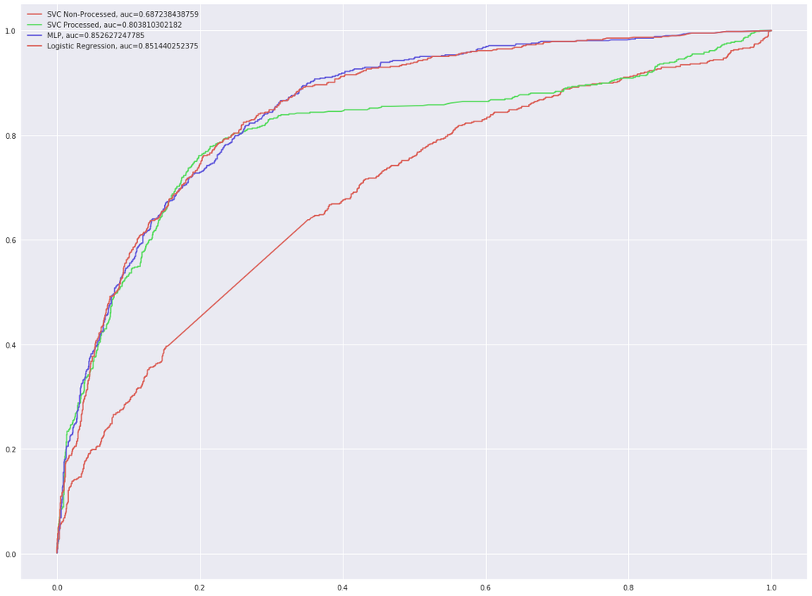

```python
# Plot SVC ROC Curve
plt.figure(0, figsize=(20,15)).clf()

fpr_svc_npp, tpr_svc_npp, thresh_svc_npp = metrics.roc_curve(y_test_npp, y_score_svc_npp)
auc_svc_npp = metrics.roc_auc_score(y_test_npp, y_score_svc_npp)
plt.plot(fpr_svc_npp, tpr_svc_npp, label="SVC Non-Processed, auc=" + str(auc_svc_npp))

fpr_svc, tpr_svc, thresh_svc = metrics.roc_curve(y_test, y_score_svc)
auc_svc = metrics.roc_auc_score(y_test, y_score_svc)
plt.plot(fpr_svc, tpr_svc, label="SVC Processed, auc=" + str(auc_svc))

fpr_mlp, tpr_mlp, thresh_mlp = metrics.roc_curve(y_test, y_score_mlp)
auc_mlp = metrics.roc_auc_score(y_test, y_score_mlp)
plt.plot(fpr_mlp, tpr_mlp, label="MLP, auc=" + str(auc_mlp))

fpr_lr, tpr_lr, thresh_lr = metrics.roc_curve(y_test, y_score_lr)
auc_lr = metrics.roc_auc_score(y_test, y_score_lr)
plt.plot(fpr_lr, tpr_lr, label="Logistic Regression, auc=" + str(auc_lr))

plt.legend(loc=0)
```

#### Bonus: Sending the trained model to the cloud and scoring through a web app

```python
# The code was removed by Watson Studio for sharing.
```

```python
# To work with the Watson Machine Learning REST API you must generate a Bearer access token

import urllib3, requests, json

headers = urllib3.util.make_headers(basic_auth='{}:{}'.format(credentials['username'], credentials['password']))
url = '{}/v3/identity/token'.format(credentials['url'])
response = requests.get(url, headers=headers)
ml_token = 'Bearer ' + json.loads(response.text).get('token')
```

```python
# Create an online scoring endpoint

endpoint_instance = credentials['url'] + "/v3/wml_instances/" + credentials['instance_id']
header = {'Content-Type': 'application/json', 'Authorization': ml_token}

response_get_instance = requests.get(endpoint_instance, headers=header)
print(response_get_instance)
print(response_get_instance.text)
```

```
<Response [200]>
{"metadata":{"guid":"461ebac2-ce8e-44e6-b3b9-b6f42a5f31b6","url":"https://instances/v3/wml_instances/461ebac2-ce8e-44e6-b3b9-b6f42a5f31b6","created_at":"2018-03-29T16:59:06.075Z","modified_at":"2018-03-29T16:59:06.075Z"},"entity":{"source":"Bluemix","published_models":{"url":"https://ibm-watson-ml.m…
```

```python
# Create API client

from watson_machine_learning_client import WatsonMachineLearningAPIClient

client = WatsonMachineLearningAPIClient(credentials)
```

```python
# Publish model in Watson Machine Learning repository on Cloud

model_props = {client.repository.ModelMetaNames.AUTHOR_NAME: "Heba El-Shimy",
               client.repository.ModelMetaNames.NAME: "Customer Churn Prediction Model"}
```

```python
published_model = client.repository.store_model(model=model, meta_props=model_props, \
                                                training_data=X_train_scaled, training_target=y_train)
```

```python
models_details = client.repository.list_models()
```

```
------------------------------------  ----------------------------------------  ------------------------  -----------------
GUID                                  NAME                                      CREATED                   FRAMEWORK
162b0769-ac37-4c2c-90bd-300a5bcc6ecb  Customer Churn Prediction Model           2018-05-06T07:47:06.648Z  scikit-learn-0.19
c76ac134-1259-440b-aab6-1009369a1967  Credit Card Approval Model                2018-05-10T18:30:13.578Z  scikit-learn-0.19
7611e82c-a519-4ed9-8dcf-ac9281dfda99  Loan Approval Model                       2018-05-10T23:01:49.846Z  scikit-learn-0.19
1c646d85-8d15-404e-b44d-2b7657d374a2  Credit Card Approval Automatic Modeler    2018-05-10T23:43:22.542Z  wml-1.1
0db64db4-586a-4552-a283-d5fd41cee2fc  Loan Approval SPSS Modeler                2018-05-11T11:20:10.702Z  spss-modeler-18.1
8941bc11-a504-443a-a664-d2cf0dc783de  Signature Fraud Detection Neural Network  2018-05-13T05:12:12.542Z  tensorflow-1.5
97debe0b-b0b2-4fac-b9f7-b2f04103f1aa  Credit Card Approval Model                2018-05-14T08:41:57.923Z  scikit-learn-0.19
7c9c36dd-73aa-43e9-b6d6-2faf71b95500  SPSS                                      2018-05-14T10:57:52.616Z  spss-modeler-18.1
7d6c25b3-915c-4aec-8437-03550a86fb6f  Test                                      2018-05-14T11:02:16.759Z  wml-1.1
11d89db6-6a98-48ac-88c5-81a5a60e7594  Customer Churn Prediction Model           2018-05-16T13:00:07.582Z  scikit-learn-0.19
------------------------------------  ----------------------------------------  ------------------------  -----------------
```

```python
#client.repository.delete('d5e07646-015f-4d59-9171-3ebdf8ccd69f')
```

```python
# Create model deployment

published_model_uid = client.repository.get_model_uid(published_model)
created_deployment = client.deployments.create(published_model_uid, "Deployment of Customer Churn Prediction Model")
```

```
#######################################################################################

Synchronous deployment creation for uid: 'cb24b5e6-7029-498c-830c-055e656ce1a3' started

#######################################################################################


INITIALIZING
DEPLOY_SUCCESS


------------------------------------------------------------------------------------------------
Successfully finished deployment creation, deployment_uid='cb24b5e6-7029-498c-830c-055e656ce1a3'
------------------------------------------------------------------------------------------------
```

```python
# Get Scoring URL
scoring_endpoint = client.deployments.get_scoring_url(created_deployment)

print(scoring_endpoint)
```

```
https://ibm-watson-ml.mybluemix.net/v3/wml_instances/461ebac2-ce8e-44e6-b3b9-b6f42a5f31b6/published_models/162b0769-ac37-4c2c-90bd-300a5bcc6ecb/deployments/cb24b5e6-7029-498c-830c-055e656ce1a3/online
```

```python
#scoring_endpoint = "https://ibm-watson-ml.mybluemix.net/v3/wml_instances/461ebac2-ce8e-44e6-b3b9-b6f42a5f31b6/published_models/162b0769-ac37-4c2c-90bd-300a5bcc6ecb/deployments/cb24b5e6-7029-498c-830c-055e656ce1a3/online"
```

```python
# Get model details and expected input
model_details = client.repository.get_details(published_model_uid)
print(json.dumps(model_details, indent=2))
```

```
{
  "metadata": {
    "guid": "162b0769-ac37-4c2c-90bd-300a5bcc6ecb",
    "url": "https://ibm-watson-ml.mybluemix.net/v3/wml_instances/461ebac2-ce8e-44e6-b3b9-b6f42a5f31b6/published_models/162b0769-ac37-4c2c-90bd-300a5bcc6ecb",
    "modified_at": "2018-05-06T07:47:19.361Z",
    "created_at": "2018-05-06T07:47:06.648Z"
  },
  "entity": {
    "author": {
      "name": "Heba El-Shimy"
    },
    "training_data_schema": {
      "features": {
        "type": "ndarray",
        "fields": [
          {
            "type": "float",
            "name": "f0"
          },
          {
            "type": "float",
            "name": "f1"
          },
          {
            "type": "float",
            "name": "f2"
          },
          {
            "type": "float",
            "name": "f3"
          },
          {
            "type": "float",
            "name": "f4"
          },
          {
            "type": "float",
            "name": "f5"
          },
          {
```

[output cut: 211 more lines]

```
    "learning_configuration_url": "https://ibm-watson-ml.mybluemix.net/v3/wml_instances/461ebac2-ce8e-44e6-b3b9-b6f42a5f31b6/published_models/162b0769-ac37-4c2c-90bd-300a5bcc6ecb/learning_configuration",
    "deployments": {
      "count": 1,
      "url": "https://ibm-watson-ml.mybluemix.net/v3/wml_instances/461ebac2-ce8e-44e6-b3b9-b6f42a5f31b6/published_models/162b0769-ac37-4c2c-90bd-300a5bcc6ecb/deployments"
    },
    "feedback_url": "https://ibm-watson-ml.mybluemix.net/v3/wml_instances/461ebac2-ce8e-44e6-b3b9-b6f42a5f31b6/published_models/162b0769-ac37-4c2c-90bd-300a5bcc6ecb/feedback",
    "deployed_version": {
      "guid": "ca015f46-49c7-4bd3-91f6-472ff04201f7",
      "url": "https://ibm-watson-ml.mybluemix.net/v3/ml_assets/models/162b0769-ac37-4c2c-90bd-300a5bcc6ecb/versions/ca015f46-49c7-4bd3-91f6-472ff04201f7"
    },
    "label_col": "l1",
    "runtime_environment": "python-3.5",
    "name": "Customer Churn Prediction Model"
  }
}
```

### Test the model

```python
# Prepare the payload to be sent to the model
payload = {
    "fields": [
        "tenure",
        "OnlineSecurity_No",
        "TechSupport_No",
        "Contract_Month-to-month",
        "MonthlyCharges_OnlineSecurity_No",
        "MonthlyCharges_TechSupport_No",
        "MonthlyCharges_Contract_Month-to-month",
        "Dependents_No_OnlineSecurity_No",
        "Dependents_No_TechSupport_No",
        "Dependents_No_Contract_Month-to-month",
        "PhoneService_Yes_Contract_Month-to-month",
        "InternetService_Fiber optic_OnlineSecurity_No",
        "InternetService_Fiber optic_TechSupport_No",
        "InternetService_Fiber optic_Contract_Month-to-month",
        "InternetService_Fiber optic_PaymentMethod_Electronic check",
        "OnlineSecurity_No_OnlineBackup_No",
        "OnlineSecurity_No_TechSupport_No",
        "OnlineSecurity_No_Contract_Month-to-month",
        "OnlineSecurity_No_PaymentMethod_Electronic check",
        "OnlineBackup_No_Contract_Month-to-month",
        "DeviceProtection_No_Contract_Month-to-month",
        "TechSupport_No_Contract_Month-to-month",
        "TechSupport_No_PaymentMethod_Electronic check",
        "Contract_Month-to-month_PaperlessBilling_Yes",
        "Contract_Month-to-month_PaymentMethod_Electronic check"
 ],
    "values": [
        [20.0, 0.0, 1.0, 0.0, 60.55, 10.0, 15.0, 0.0, 0.0, 0.0, 0.0, 0.0, 1.0, 1.0, 1.0, 1.0, 0.0, 0.0, 0.0, 0.0, 0.0, 0.0, 0.0, 0.0, 0.0]
 ]
}
```

```python
# Send data to the model and print results
predictions = client.deployments.score(scoring_endpoint, payload)
print(json.dumps(predictions, indent=2))
```

```
{
  "values": [
    [
      1,
      [
        1.2567231699733838e-09,
        0.9999999987432768
      ]
    ]
  ],
  "fields": [
    "prediction",
    "probability"
  ]
}
```

#### Sending data to the model

Sending new data (may be collected from web/mobile app) in the format the model is excpecting as shown above.  
We get back a response with the predicted class (1 - Customer with sent data will churn)  
and probabilities of both classes (0 or No Curn has a probability of 1.2567231699733838e-9 which is very small, 1 or Churn has a probability of 0.9999999987432768 which means the model is confident of its prediction)

[figure not shown]

## References:

#### <sub>[1] https://www.sciencedirect.com/science/article/abs/pii/S0148296318301231 "Customer churn prediction in telecommunication industry using data certainty"</sub>

#### <sub>[2] https://www.signal.co/blog/understanding-customer-churn/ "10 Stats Expose the Real Connection Between Customer Experience and Customer Churn"</sub>

#### <sub>[3] https://www.pinterest.com/pin/456904324667676431/ "Mobile Telco Churn Infographic"</sub>

#### <sub>[4] https://pandas.pydata.org/pandas-docs/stable/ "Pandas Documentation"</sub>

#### <sub>[5] http://scikit-learn.org/stable/modules/generated/sklearn.preprocessing.Imputer.html "Scikit-Learn Imputer"</sub>

#### <sub>[6] https://github.com/ibm-watson-data-lab/pixiedust/wiki/Tutorial:-Extending-the-PixieDust-Visualization "PixieDust Documentation"</sub>

#### <sub>[7] https://seaborn.pydata.org/ "Seaborn Documentation"</sub>

#### <sub>[8] http://scikit-learn.org/stable/modules/generated/sklearn.preprocessing.LabelEncoder.html#sklearn.preprocessing.LabelEncoder "Scikit-Learn LabelEncoder"</sub>

#### <sub>[9] http://colingorrie.github.io/outlier-detection.html "Outlier Detection Methods"</sub>

#### <sub>[10] http://scikit-learn.org/stable/auto_examples/linear_model/plot_polynomial_interpolation.html#sphx-glr-auto-examples-linear-model-plot-polynomial-interpolation-py "Scikit-Learn Polynomial"</sub>

#### <sub>[11] http://scikit-learn.org/stable/modules/feature_selection.html "Scikit-Learn Feature Selection"</sub>

#### <sub>[12] http://scikit-learn.org/stable/modules/generated/sklearn.preprocessing.StandardScaler.html#sklearn.preprocessing.StandardScaler "Scikit-Learn StandardScaler"</sub>

#### <sub>[13] http://scikit-learn.org/stable/modules/generated/sklearn.svm.SVC.html#sklearn.svm.SVC "Scikit-Learn SVC"</sub>

#### <sub>[14] http://scikit-learn.org/stable/modules/generated/sklearn.linear_model.LogisticRegression.html#sklearn.linear_model.LogisticRegression "Scikit-Learn Logistic Regression"</sub>

#### <sub>[15] http://scikit-learn.org/stable/modules/generated/sklearn.neural_network.MLPClassifier.html "Scikit-Learn MLP Classifier"</sub>

#### <sub>[16] http://scikit-learn.org/stable/modules/generated/sklearn.metrics.accuracy_score.html#sklearn.metrics.accuracy_score "Scikit-Learn Accuracy Score"</sub>

#### <sub>[17] http://scikit-learn.org/stable/modules/generated/sklearn.metrics.average_precision_score.html#sklearn.metrics.average_precision_score "Scikit-Learn Average Precision Score"</sub>

#### <sub>[18] https://www.sciencedirect.com/science/article/pii/S016786550500303X "An introduction to ROC analysis"</sub>

#### <sub>[19] https://wml-api-pyclient.mybluemix.net/ "Watson Machine Learning Client Documentation"</sub>

#### <sub>[20] https://dataplatform.ibm.com/docs/content/analyze-data/ml-deploy-notebook.html?context=analytics "IBM Watson Studio Documentation-Deploy a model from a notebook"</sub>